# Avaliação técnica — Quaest, Data Scientist Jr.

André M. G. Costa

30/04/2021

## Introdução

Esta págnia contém o código, a descrição dos processos e os resultados obtidos para a segunda etapa do processo seletivo para Data Scientist Jr. da Quaest.

O código também se encontra no projeto que hospeda esta página: O arquivo Main.R chama três arquivos na pasta ‘./Code/Tasks’, cada um feito para uma tarefa solicitada. Tais arquivos se utilizam de funções que se encontram na pasta ‘./Code/Functions’, sendo uma relacionada ao tratamento dos dados de entrada e duas relacionadas à geração de tabelas de contingência.

Para este trabalho, foi utilizado o R versão 4.0.5 e os pacotes: ggplot2_3.3.3; stringr_1.4.0; forcats_0.5.1; dplyr_1.0.5; openxlsx_4.2.3

## Leitura e tratamento da entrada

### Descrição

#### Leitura da entrada

Para leitura da tabela fornecida, foi utilizada a função `read.xlsx()` do pacote `openxlsx`, versão **4.2.3**, com o comando.

```r
entrada <- read.xlsx("./Data/bd_surveyquaest.xlsx",sheet=1)
```

#### Processamento dos dados

Para realizar o processamento de dados, foi criada a função `trata_entrada()`, cujo código pode ser visto na aba correspondente e que realiza os seguintes procedimentos:

1. Transforma as colunas do tipo `charater` em `factor`.
2. Ordena os níveis de fatores de intenção de voto de acordo com a frequência da resposta, mas colocando os níveis de `Ninguém/Branco/Nulo` e `NS/NR` ao final.
3. Ordena os níveis dos fatores das outras variáveis de modo e terem um padrão crescente.
4. Reduz algumas descrições de categorias, especialmente a de renda familiar.
5. De maneira opcional, diminui o número de níveis nos fatores de educação, renda e avaliação do governo, agrupando alguns níveis. Os critérios para cada caso estão comentados no código fonte
6. De maneira opcional, transforma os dados de idade em categóricos, seguindo o padrão de idades utilizado pelo Datafolha.

A seguir, mostra-se o uso da função criada:

```r
survey <- trata_entrada(entrada)
```

### trata_entrada()

```r
trata_entrada <- function (entrada,
                           reduz_rendaf = T,
                           reduz_esc = T,
                           reduz_aval = T,
                           categoriza_idade = T
){


    saida <- entrada %>%
        # Transformando variaveis chr em fct
        mutate_if(is.character,as.factor) %>%

        # Ordenando voto de acordo com a frequencia
        mutate(voto1 = voto1 %>% fct_infreq %>%
                   # Colocando "Ninguém/Branco/Nulo" e "NS/NR" no final
                   fct_relevel("Ninguém/Branco/Nulo","NS/NR", after = Inf)
        ) %>%

        # Renomeando e reordenando fatores de renda fixa
        mutate(rendaf = rendaf %>% fct_relabel(function(x)
            # Obtem conteúdo entre parênteses
            x %>%  str_extract("\\(.*\\)$") %>%
                # Remove caracteres especiais
                str_remove_all("[^[:alnum:] ]") %>%
                # Remove barra de espaço no inicio
                str_remove("^ ") %>%
                # Coloca um barra de espaço entre número e SM
                str_replace("([0-9])S", "\\1 S") %>%
                # Remove a palaVra SM
                str_remove_all(" SM") %>%
                # Ajuste para último level
                str_replace("^de 20$", "mais de 20"))

            # Reordendnando fatores
            %>% fct_relevel(
                "de 10 até 15", "de 15 até 20", after = 5)
        )


    if(reduz_rendaf){
        saida <- saida %>%
            mutate(rendaf = rendaf %>% fct_collapse(
                "mais de 10" = c("de 10 até 15",
                                 "de 15 até 20",
                                 "mais de 20")
            )
            )
    }


    # Se solicitado, reduz o número de fatores de escolaridade, considerando se
    # completou ensino fundamental, médio e superior.
    # Se não solicitado, apenas reordenamos os fatores.

    if(reduz_esc){
        saida <- saida %>%
            mutate(esc = esc %>% fct_collapse(
                "Não completou EF" = c(
                    "Sem instrução e menos de 1 ano de estudo",
                    "Ensino fundamental incompleto"),
                "Ensino Fundamental" = c(
                    "Ensino fundamental completo",
                    "Ensino médio incompleto"),
                "Ensino Médio" = c(
                    "Ensino médio completo",
                    "Ensino superior incompleto") ,
                "Ensino Superior" =  "Ensino superior completo") %>%

                    fct_relevel("Não completou EF")
            )
    } else {
        saida <- saida %>%
            mutate(esc = esc %>% fct_relevel(
                "Sem instrução e menos de 1 ano de estudo",
                "Ensino fundamental incompleto",
                "Ensino fundamental completo",
                "Ensino médio incompleto",
                "Ensino médio completo",
                "Ensino superior incompleto",
                "Ensino superior completo"
            ))
    }

    # Se solicitado, reduz o número de categorias de avaliação do governo em
    # boa/ótima, regular e ruim/péssima.
    # Se não solicitado, apenas reordena os fatores.

    if(reduz_aval){
        saida <- saida %>%
            # Ordenando avaliação do governo
            mutate(aval_gov = aval_gov %>% fct_collapse(
                "Boa/Ótima" = c("Boa", "Ótima"),
                "Regular" = c("Regular positiva", "Regular negativa"),
                "Ruim/Péssima" = c("Ruim", "Péssima")
            ) %>% fct_relevel(c("Boa/Ótima","Regular","Ruim/Péssima")))
    } else {
        saida <- saida %>%
            mutate(aval_gov = aval_gov %>% fct_relevel(
                "Péssima",
                "Ruim" ,
                "Regular negativa",
                "Regular positiva",
                "Boa",
                "Ótima" ,
                "NS/NR"
            ))
    }



    # Se solicitado, transforma idade em fatores de acordo com critério utilizado
    # pelo Datafolha

    if(categoriza_idade){
        saida <- saida %>%
            mutate(idade = idade %>% cut(breaks = c(0, 24, 34, 44, 59, 200)) %>%
                       fct_recode("de 16 a 24" = "(0,24]",
                                  "de 25 a 34" = "(24,34]",
                                  "de 35 a 44" = "(34,44]",
                                  "de 45 a 59" = "(44,59]",
                                  "mais de 60" = "(59,200]")
            )
    }
}
```

## Função para criação de tabelas de contingência

### Descrição

Foi criada uma função `tabela_convergencia()` para criação de tabelas de contingência. Tal função recebe, em formato de vetor de `character`, quais variáveis deseja-se avaliar junto à variável de voto estimado (é possível escolher outra variável de reverência com a entrada `varref`). A função também recebe um `data.frame` para utilizar como referência, por padrão considera um `data.frame` chamado *survey*.

Além disso, a função permite, por meio da variável `porcentagem`, que a tabela apresente os dados em porcentagem, ao invés de absoluto. Com a variável `dimensao`, pode-se definir se queremos a porcentagem relativa a uma ou mais variáveis, por meio do trecho de código : `tabela %>% prop.table(dimensao)`. A função também permite adicionar margens à tabela gerada, com a soma dos valores de dimensões.

A função retorna uma tabela cruzada do tipo `table` para multivariada e `xtabs` para monovariada. Seu código fonte pode ser visto na aba correspondente e alguns exemlos de utilização podem ser vistos na aba **Exemplos**.

Além desta função, foi criada uma função para gerar e imprimir as tabelas bivariadas contendo a intenção de voto e todas as outras variáveis categóricas do `data.frame`. Essa função, `tabelas_bivar()`, pode ser vista na aba correspondente.

### tabela_contingência()

```r
tabela_contingencia <-function(variavel,
                               df = survey,
                               porcentagem = T,
                               dimensao = NULL,
                               margens = F,
                               varref = "voto1"){

    if(!is.character(variavel))
        stop("A entrada 'variavel' deve ser do tipo character")
    if(!(porcentagem %in% c(0,1,2) ))
        stop("A entrada 'porcentagem' deve ser 0, 1 ou 2")
    if(sum (variavel %in% names(df) ) < length(variavel) )
        stop("A entrada 'variavel' deve conter apenas nomes de coluna de 'df'")
    if(anyDuplicated(variavel))
        stop("A entrada 'variavel' não deve conter valores repetidos")


    f <- as.formula(paste(paste0("~",varref,"+"),
                          paste(variavel, collapse="+")))

    tabela <-  xtabs(f,df)

    if (porcentagem){
        tabela <- tabela %>% prop.table(dimensao) %>% `*`(100) %>% round(1)
    }

    if (margens){
        tabela <- tabela %>% addmargins()
    }

    return(tabela)
}
```

### Exemplos

Estes exemplos também estão no arquivo “./Code/Tasks/Tabelas.R”.

#### As mulheres e os homens estão votando no mesmo candidato ?

Analisando a tabela, parece haver uma maior preferência feminina ao candidato 2 em relação aos homens, enquanto os homens parecem apresentar maior tendência a votar no candidato 1.

```r
pergunta = tabela_contingencia("sexo", dimensao = 2)
knitr::kable(pergunta)
```

|  | Feminino | Masculino |
| --- | --- | --- |
| Candidato 2 | 54.1 | 50.1 |
| Candidato 1 | 2.0 | 6.8 |
| Candidato 8 | 2.6 | 2.6 |
| Candidato 5 | 2.6 | 2.4 |
| Candidato 10 | 2.6 | 1.3 |
| Candidato 9 | 1.3 | 2.6 |
| Candidato 3 | 1.7 | 1.5 |
| Candidato 4 | 0.7 | 1.8 |
| Candidato 6 | 1.3 | 0.7 |
| Candidato 7 | 0.6 | 0.9 |
| Candidato 12 | 0.6 | 0.7 |
| Candidato 14 | 1.1 | 0.0 |
| Candidato 11 | 0.2 | 0.4 |
| Candidato 13 | 0.4 | 0.2 |
| Ninguém/Branco/Nulo | 13.2 | 15.4 |
| NS/NR | 15.2 | 12.5 |

#### Exemplo simples bivariada com dados absolutos

```r
sexo = tabela_contingencia("sexo", porcentagem = F)
knitr::kable(sexo)
```

|  | Feminino | Masculino |
| --- | --- | --- |
| Candidato 2 | 295 | 228 |
| Candidato 1 | 11 | 31 |
| Candidato 8 | 14 | 12 |
| Candidato 5 | 14 | 11 |
| Candidato 10 | 14 | 6 |
| Candidato 9 | 7 | 12 |
| Candidato 3 | 9 | 7 |
| Candidato 4 | 4 | 8 |
| Candidato 6 | 7 | 3 |
| Candidato 7 | 3 | 4 |
| Candidato 12 | 3 | 3 |
| Candidato 14 | 6 | 0 |
| Candidato 11 | 1 | 2 |
| Candidato 13 | 2 | 1 |
| Ninguém/Branco/Nulo | 72 | 70 |
| NS/NR | 83 | 57 |

#### Exemplo simples bivariada com dados em porcento

```r
aval_gov = tabela_contingencia("aval_gov")
knitr::kable(aval_gov)
```

|  | Boa/Ótima | Regular | Ruim/Péssima | NS/NR |
| --- | --- | --- | --- | --- |
| Candidato 2 | 45.4 | 6.6 | 0.2 | 0.1 |
| Candidato 1 | 1.7 | 1.7 | 0.8 | 0.0 |
| Candidato 8 | 0.5 | 1.0 | 1.1 | 0.0 |
| Candidato 5 | 1.1 | 1.1 | 0.3 | 0.0 |
| Candidato 10 | 0.8 | 0.9 | 0.3 | 0.0 |
| Candidato 9 | 0.8 | 0.7 | 0.4 | 0.0 |
| Candidato 3 | 0.8 | 0.6 | 0.2 | 0.0 |
| Candidato 4 | 0.6 | 0.6 | 0.0 | 0.0 |
| Candidato 6 | 0.4 | 0.5 | 0.1 | 0.0 |
| Candidato 7 | 0.1 | 0.4 | 0.2 | 0.0 |
| Candidato 12 | 0.4 | 0.1 | 0.1 | 0.0 |
| Candidato 14 | 0.3 | 0.2 | 0.1 | 0.0 |
| Candidato 11 | 0.1 | 0.0 | 0.2 | 0.0 |
| Candidato 13 | 0.2 | 0.1 | 0.0 | 0.0 |
| Ninguém/Branco/Nulo | 4.4 | 5.5 | 3.8 | 0.5 |
| NS/NR | 4.8 | 4.9 | 3.5 | 0.8 |

#### Exemplo bivariada com dados em porcento e margens

```r
esc = tabela_contingencia("esc", margens = T)
knitr::kable(esc)
```

|  | Não completou EF | Ensino Fundamental | Ensino Médio | Ensino Superior | Sum |
| --- | --- | --- | --- | --- | --- |
| Candidato 2 | 11.5 | 9.3 | 22.2 | 9.3 | 52.3 |
| Candidato 1 | 1.4 | 0.4 | 1.4 | 1.0 | 4.2 |
| Candidato 8 | 0.1 | 0.3 | 1.1 | 1.1 | 2.6 |
| Candidato 5 | 0.0 | 0.2 | 1.3 | 1.0 | 2.5 |
| Candidato 10 | 0.3 | 0.4 | 1.1 | 0.2 | 2.0 |
| Candidato 9 | 0.3 | 0.6 | 0.8 | 0.2 | 1.9 |
| Candidato 3 | 0.4 | 0.1 | 0.8 | 0.3 | 1.6 |
| Candidato 4 | 0.3 | 0.0 | 0.5 | 0.4 | 1.2 |
| Candidato 6 | 0.1 | 0.2 | 0.5 | 0.2 | 1.0 |
| Candidato 7 | 0.2 | 0.1 | 0.3 | 0.1 | 0.7 |
| Candidato 12 | 0.2 | 0.1 | 0.1 | 0.2 | 0.6 |
| Candidato 14 | 0.0 | 0.3 | 0.1 | 0.2 | 0.6 |
| Candidato 11 | 0.1 | 0.0 | 0.1 | 0.1 | 0.3 |
| Candidato 13 | 0.0 | 0.1 | 0.2 | 0.0 | 0.3 |
| Ninguém/Branco/Nulo | 2.4 | 2.5 | 7.4 | 1.9 | 14.2 |
| NS/NR | 2.8 | 2.7 | 5.2 | 3.3 | 14.0 |
| Sum | 20.1 | 17.3 | 43.1 | 19.5 | 100.0 |

#### Exemplo bivariada com dados em porcento em relação ao voto

**Significado**: Quantos porcento dos que disseram votar em um candidato estão em cada categoria de idade

```r
idade = tabela_contingencia("idade", dimensao = 1)
knitr::kable(idade)
```

|  | de 16 a 24 | de 25 a 34 | de 35 a 44 | de 45 a 59 | mais de 60 |
| --- | --- | --- | --- | --- | --- |
| Candidato 2 | 12.2 | 17.8 | 19.5 | 25.4 | 25.0 |
| Candidato 1 | 2.4 | 16.7 | 23.8 | 28.6 | 28.6 |
| Candidato 8 | 11.5 | 26.9 | 19.2 | 30.8 | 11.5 |
| Candidato 5 | 12.0 | 36.0 | 36.0 | 16.0 | 0.0 |
| Candidato 10 | 25.0 | 30.0 | 20.0 | 15.0 | 10.0 |
| Candidato 9 | 21.1 | 26.3 | 21.1 | 26.3 | 5.3 |
| Candidato 3 | 25.0 | 18.8 | 12.5 | 12.5 | 31.2 |
| Candidato 4 | 0.0 | 0.0 | 8.3 | 58.3 | 33.3 |
| Candidato 6 | 20.0 | 30.0 | 30.0 | 10.0 | 10.0 |
| Candidato 7 | 14.3 | 14.3 | 14.3 | 14.3 | 42.9 |
| Candidato 12 | 0.0 | 16.7 | 16.7 | 66.7 | 0.0 |
| Candidato 14 | 33.3 | 33.3 | 33.3 | 0.0 | 0.0 |
| Candidato 11 | 0.0 | 33.3 | 0.0 | 66.7 | 0.0 |
| Candidato 13 | 0.0 | 33.3 | 0.0 | 33.3 | 33.3 |
| Ninguém/Branco/Nulo | 13.4 | 19.0 | 19.7 | 25.4 | 22.5 |
| NS/NR | 17.1 | 13.6 | 21.4 | 24.3 | 23.6 |

#### Exemplo bivariada com dados em porcento em relação à outra variável

**Significado**: Quantos porcento dos que tem certa renda dizem votar em cada candidato

```r
rendaf = tabela_contingencia("rendaf", dimensao = 2)
knitr::kable(rendaf)
```

|  | até 1 | de 1 até 2 | de 2 até 3 | de 3 até 5 | de 5 até 10 | mais de 10 |
| --- | --- | --- | --- | --- | --- | --- |
| Candidato 2 | 51.7 | 56.1 | 47.6 | 54.2 | 50.9 | 51.9 |
| Candidato 1 | 2.0 | 4.9 | 4.8 | 4.0 | 6.4 | 3.8 |
| Candidato 8 | 1.0 | 0.8 | 3.3 | 3.4 | 6.4 | 3.8 |
| Candidato 5 | 0.5 | 1.2 | 3.3 | 5.1 | 2.7 | 3.8 |
| Candidato 10 | 2.4 | 2.4 | 1.4 | 1.7 | 0.9 | 3.8 |
| Candidato 9 | 2.9 | 2.0 | 1.4 | 1.7 | 0.9 | 1.9 |
| Candidato 3 | 1.0 | 2.0 | 2.4 | 1.1 | 1.8 | 0.0 |
| Candidato 4 | 0.5 | 1.6 | 1.0 | 0.6 | 2.7 | 1.9 |
| Candidato 6 | 1.0 | 1.2 | 1.9 | 0.6 | 0.0 | 0.0 |
| Candidato 7 | 0.5 | 1.2 | 0.5 | 0.0 | 0.9 | 1.9 |
| Candidato 12 | 1.0 | 0.4 | 0.5 | 0.0 | 1.8 | 0.0 |
| Candidato 14 | 0.5 | 0.8 | 1.0 | 0.0 | 0.9 | 0.0 |
| Candidato 11 | 0.0 | 1.2 | 0.0 | 0.0 | 0.0 | 0.0 |
| Candidato 13 | 0.5 | 0.4 | 0.5 | 0.0 | 0.0 | 0.0 |
| Ninguém/Branco/Nulo | 18.5 | 14.6 | 15.7 | 10.7 | 9.1 | 11.5 |
| NS/NR | 16.1 | 8.9 | 14.8 | 16.9 | 14.5 | 15.4 |

#### Exemplo multivariada simples com dados em porcento e margens

**Atenção**: Os exemplos multivariados são melhor visualizados gerando no console

```r
rendaf_sexo =  tabela_contingencia(c("rendaf","sexo"), margens = T)
knitr::kable(rendaf_sexo)
```

| voto1 | rendaf | sexo | Freq |
| --- | --- | --- | --- |
| Candidato 2 | até 1 | Feminino | 6.7 |
| Candidato 1 | até 1 | Feminino | 0.1 |
| Candidato 8 | até 1 | Feminino | 0.2 |
| Candidato 5 | até 1 | Feminino | 0.1 |
| Candidato 10 | até 1 | Feminino | 0.4 |
| Candidato 9 | até 1 | Feminino | 0.4 |
| Candidato 3 | até 1 | Feminino | 0.2 |
| Candidato 4 | até 1 | Feminino | 0.0 |
| Candidato 6 | até 1 | Feminino | 0.2 |
| Candidato 7 | até 1 | Feminino | 0.1 |
| Candidato 12 | até 1 | Feminino | 0.1 |
| Candidato 14 | até 1 | Feminino | 0.1 |
| Candidato 11 | até 1 | Feminino | 0.0 |
| Candidato 13 | até 1 | Feminino | 0.1 |
| Ninguém/Branco/Nulo | até 1 | Feminino | 2.4 |
| NS/NR | até 1 | Feminino | 2.5 |
| Sum | até 1 | Feminino | 13.6 |
| Candidato 2 | de 1 até 2 | Feminino | 7.3 |
| Candidato 1 | de 1 até 2 | Feminino | 0.3 |
| Candidato 8 | de 1 até 2 | Feminino | 0.2 |
| Candidato 5 | de 1 até 2 | Feminino | 0.3 |
| Candidato 10 | de 1 até 2 | Feminino | 0.5 |
| Candidato 9 | de 1 até 2 | Feminino | 0.2 |
| Candidato 3 | de 1 até 2 | Feminino | 0.3 |
| Candidato 4 | de 1 até 2 | Feminino | 0.2 |
| Candidato 6 | de 1 até 2 | Feminino | 0.1 |
| Candidato 7 | de 1 até 2 | Feminino | 0.2 |
| Candidato 12 | de 1 até 2 | Feminino | 0.0 |
| Candidato 14 | de 1 até 2 | Feminino | 0.2 |
| Candidato 11 | de 1 até 2 | Feminino | 0.1 |

[output cut: 327 more lines]

#### Exemplo multivariada simples com dados em porcento para uma dada intenção de voto e um dado sexo.

**Atenção**: Os exemplos multivariados são melhor visualizados gerando no console

```r
idade_sexo = tabela_contingencia(c("idade", "sexo"), dimensao = c(1,3))
knitr::kable(idade_sexo)
```

| voto1 | idade | sexo | Freq |
| --- | --- | --- | --- |
| Candidato 2 | de 16 a 24 | Feminino | 9.5 |
| Candidato 1 | de 16 a 24 | Feminino | 0.0 |
| Candidato 8 | de 16 a 24 | Feminino | 7.1 |
| Candidato 5 | de 16 a 24 | Feminino | 14.3 |
| Candidato 10 | de 16 a 24 | Feminino | 21.4 |
| Candidato 9 | de 16 a 24 | Feminino | 14.3 |
| Candidato 3 | de 16 a 24 | Feminino | 11.1 |
| Candidato 4 | de 16 a 24 | Feminino | 0.0 |
| Candidato 6 | de 16 a 24 | Feminino | 14.3 |
| Candidato 7 | de 16 a 24 | Feminino | 33.3 |
| Candidato 12 | de 16 a 24 | Feminino | 0.0 |
| Candidato 14 | de 16 a 24 | Feminino | 33.3 |
| Candidato 11 | de 16 a 24 | Feminino | 0.0 |
| Candidato 13 | de 16 a 24 | Feminino | 0.0 |
| Ninguém/Branco/Nulo | de 16 a 24 | Feminino | 18.1 |
| NS/NR | de 16 a 24 | Feminino | 18.1 |
| Candidato 2 | de 25 a 34 | Feminino | 19.3 |
| Candidato 1 | de 25 a 34 | Feminino | 27.3 |
| Candidato 8 | de 25 a 34 | Feminino | 21.4 |
| Candidato 5 | de 25 a 34 | Feminino | 21.4 |
| Candidato 10 | de 25 a 34 | Feminino | 28.6 |
| Candidato 9 | de 25 a 34 | Feminino | 42.9 |
| Candidato 3 | de 25 a 34 | Feminino | 11.1 |
| Candidato 4 | de 25 a 34 | Feminino | 0.0 |
| Candidato 6 | de 25 a 34 | Feminino | 28.6 |
| Candidato 7 | de 25 a 34 | Feminino | 33.3 |
| Candidato 12 | de 25 a 34 | Feminino | 33.3 |
| Candidato 14 | de 25 a 34 | Feminino | 33.3 |
| Candidato 11 | de 25 a 34 | Feminino | 0.0 |
| Candidato 13 | de 25 a 34 | Feminino | 0.0 |

[output cut: 130 more lines]

### tabelas_bivar()

```r
tabelas_bivar <-function(df,
                         porcentagem = T,
                         dimensao = NULL,
                         margens = F,
                         varref = "voto1",
                         ignorar = c("voto1","voto1_red","voto1_red2")){

    df <- df[,sapply(df, is.factor)]
    for (v in names(df)){
        if (!(v %in% ignorar)){
            print(tabela_contingencia(v, df, porcentagem, dimensao,
                                      margens, varref))
        }
    }

}
```

## Gráficos

### Comentários

O primeiro gráfico mostra que o candidato 2 é o grande favorito para as eleições, caso ela ocorresse no momento da pesquisa, uma vez que apresenta mais de 50% dos votos totais. Se considerarmos os votos válidos, este número ultrapassa os 70%.

Avaliando o segundo gráfico, pode-se perceber que quando se avalia o governo positivamente, há uma maior tendência a votar no candidato 2. Isto, somado às boas perspectivas deste candidato, sugerem que ele possa ser o próprio governante atual, ou um aliado próximo e conhecido.

Por outro lado, Também podemos perceber que, quanto pior se avalia o governo, maior a tendência de não saber ou dizer que não irá votar. Nesse sentido, também é interessante verificar que o candidato 8 tem uma relativa importância entre os que avaliam mal o governo, podendo ser um candidato de oposição declarada, mas não tanto conhecido, ou de visões consideradas mais radicais. É interessante ver que, dentre os que avaliam como boa ou ótima a atuação do governo, este candidato apresenta menor intenção de votos entre os 8 candidatos que mais se destacaram nessa pesquisa.

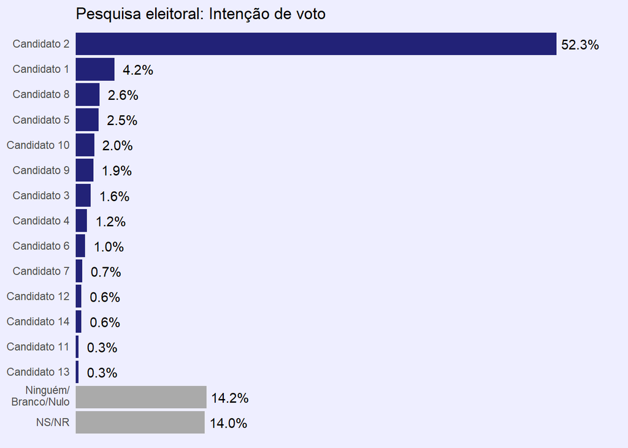

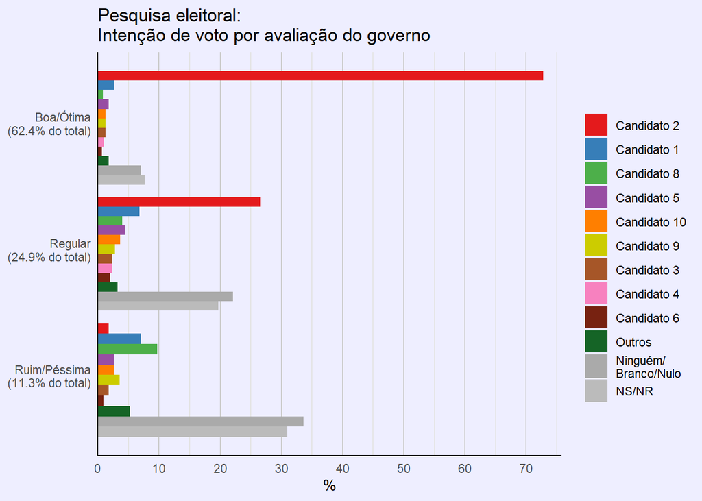

### Sobre o gráfico 1

#### Considerações

Para a tarefa do gráfico das intenções de voto, optou-se por utilizar um gráfico de barras horizontal, mostrando o valor em porcentagem em texto, como são feitos muitos dos gráficos que apresentam este tipo de informação.

A cor no fundo foi utilizada para diminuir o contraste e deixar a figura mais confortável para se ver.

#### Código e Gráfico

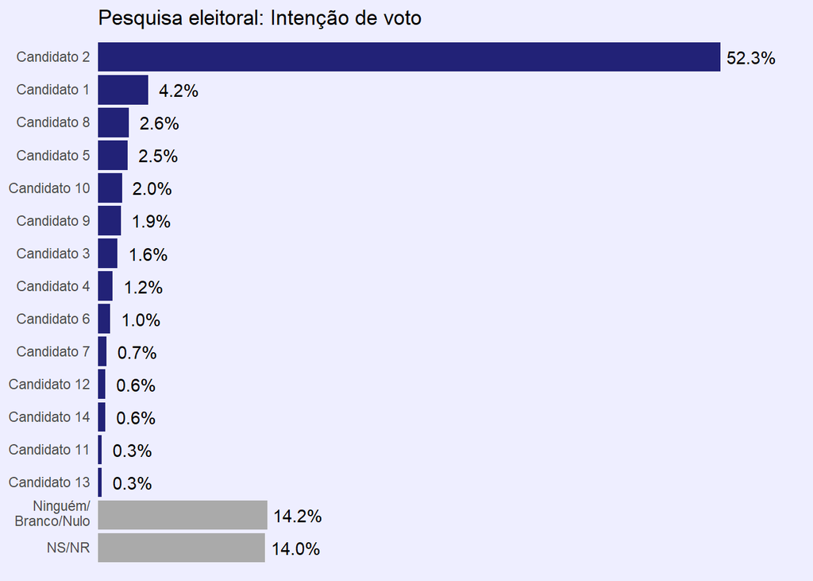

```r
# Definindo cor do fundo
cor="#EEEEFF"

# Gerando dados para o gráfico:
# obtendo porcentagem de cada voto e colocando quebra de linha em "Ninguém/..."

df_plot1 <- survey %>%
    group_by(voto1) %>% summarise(n = n()) %>% ungroup()%>%
    mutate(pct = n/sum(n)*100)%>%
    mutate(voto1 = voto1 %>%
               fct_recode("Ninguém/\nBranco/Nulo" = "Ninguém/Branco/Nulo"))

# Gerando gráfico 1

p1 <- ggplot(aes(x = fct_rev(voto1), y = pct), data = df_plot1) +
    # Barras
    geom_bar(stat = "identity", aes(fill=voto1))+
    # Texto dos valores percentis
    geom_text(aes(label = pct %>% format(nsmall=1) %>% paste0("%"),
                  y=pct +0.5, hjust=0))+
    # configurando eixo
    scale_y_continuous(expand = c(0, 0),
                       limits = c(0, max(df_plot1$pct)+7)
                       ) +
    # Ajustando cores
    scale_fill_manual(values = c(rep("#222277", 14), "#AAAAAA", "#AAAAAA"))+
    # Título
    ggtitle("Pesquisa eleitoral: Intenção de voto") +
    #Estética
    theme_classic()+
    theme(
        axis.line=element_blank(),
        axis.ticks=element_blank(),
        axis.text.x=element_blank(),
        axis.text.y = element_text(vjust = 0.4),
        axis.title.x=element_blank(),
        axis.title.y=element_blank(),
        legend.position = 'none',
        plot.background = element_rect(fill = cor, colour = cor),
        panel.background = element_rect(fill = cor, colour = cor)
    ) +
    coord_flip()

print(p1)
```

### Sobre o gráfico 2

#### Considerações

Para a tarefa do gráfico das intenções de voto junto às avaliações do governo, optou-se por utilizar uma representação similar à anterior, visando facilitar a interpretação e manter uma coerência.

Neste caso, decidiu-se por separar o gráfico em três grupos, relativos às avaliações de governo. Foram utilizadas as categorias “boa/ótima”, “regular” e “ruim/péssima”. Em cada uma dessas partes do gráfico, as barras representam a porcentagem das pessoas dessa categoria que pretendem votar em cada candidato.(Por exemplo: mais de 70% das pessoas que avaliam o governo como bom ou ótimo, pretendem votar no candidato 2.).

A escolha por representar os dados em porcentagem relativa a cada categoria se deu considerando a diferença do número de respostas em cada uma. Assim, a visualização dos dados da categoria “ruim/péssima” ficavam desconfortáveis de se analizar. Para explicitar a diferença da frequência de cada avaliação, foi colocado a porcentagem das respostas de cada categoria em texto.

A utilização das três categorias descritas acima foi definida por três razões principais:

1. Esta é a forma em que são apresentadas as principais pesquisas de aprovação de governo.
2. Reduzir o número de categorias facilita a visualização e interpretação dos dados
3. Algumas categorias possuiam muito poucos elementos, o que faz com que tenhamos mais incertezas em relação a sua representatividade

Para não poluir o gráfico, foram também retirados todos os candidatos com menos de 1% da intenção de votos, também considerando a pouca representatividade e importância destes para a análise.

#### Código e Gráfico

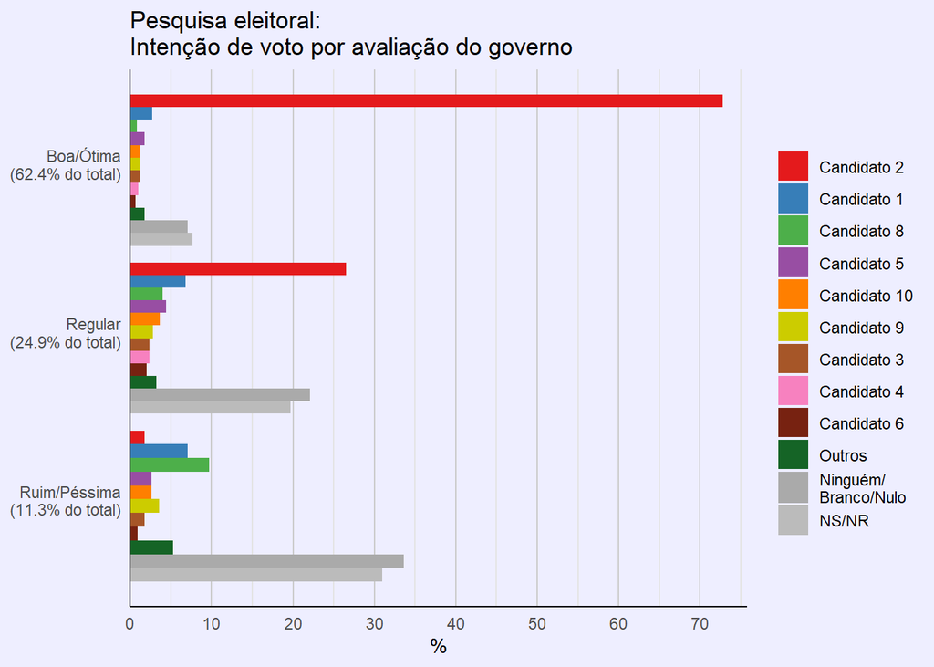

```r
# Manualmente cria coluna voto1_red,
# que considera candidatos com menos de 1.0% dos votos como outros.

survey <- survey %>%
    mutate(voto1_red = voto1 %>% fct_collapse(
        Outros = c("Candidato 7", "Candidato 12", "Candidato 14",
                   "Candidato 11", "Candidato 13"))
    )

##### Grafico 2 ####

# Definindo cor do fundo
cor="#EEEEFF"


# Gerando dados para o gráfico:
# obtendo porcentagem de cada candidato para cada aval.

df_plot2 <- survey %>%
    group_by(voto1_red,aval_gov) %>% summarise(n = n()) %>% ungroup() %>%
    group_by(aval_gov) %>%
    mutate(pct = n/sum(n)*100)%>%
    mutate(voto1_red = voto1_red %>%
               fct_recode("Ninguém/\nBranco/Nulo" = "Ninguém/Branco/Nulo")) %>%
    filter(aval_gov != "NS/NR") %>%
    mutate(aval_gov = aval_gov %>%
               fct_recode(
                   # paste0("Boa/Ótima\n",a["Boa/Ótima"],"%") ="Boa/Ótima",
                   # paste0("Regular\n",a["Regular"],"%") ="Regular",
                   "Ruim/Péssima\n11,3 %"="Ruim/Péssima"
               )
    )

# Obtendo a porcentagem das respostas de cada categoria de avaliacao

pct_aval <- table(survey$aval_gov) %>% prop.table() %>% `*`(100)


# Gerando gráfico 2

p2 <- ggplot(aes(fill=fct_rev(voto1_red), x = fct_rev(aval_gov), y = pct),
            data = df_plot2) +

    geom_bar(stat = "identity",position = "dodge")+

    scale_y_continuous(expand = c(0, 0), limits = c(0, max(df_plot2$pct)+3),
                       breaks = seq(0,70,10), minor_breaks = seq(0,75,5)) +

    scale_x_discrete(labels = c(
        paste0("Ruim/Péssima\n(",pct_aval["Ruim/Péssima"],"% do total)"),
        paste0("Regular\n(",pct_aval["Regular"],"% do total)"),
        paste0("Boa/Ótima\n(",pct_aval["Boa/Ótima"],"% do total)")))+

    scale_fill_manual(values =
                          rev(c(RColorBrewer::brewer.pal(8,"Set1")[1:5],
                                "#CCCC00",
                                RColorBrewer::brewer.pal(8,"Set1")[7:8],
                                "#772211", "#156426", "#AAAAAA", "#BBBBBB"))) +

    ggtitle("Pesquisa eleitoral:\nIntenção de voto por avaliação do governo") +
    ylab("%")+

    theme_classic()+
    guides(fill = guide_legend(reverse = TRUE))+
    theme(axis.ticks=element_blank(),
          axis.text.y = element_text(vjust = 0.3),
          panel.grid.major.x =  element_line(colour = "#CCCCCC"),
          panel.grid.minor.x =  element_line(colour = "#E4E4E4"),
          axis.title.y = element_blank(),
          plot.background = element_rect(fill = cor, colour = cor),
          panel.background = element_rect(fill = cor, colour = cor),
          legend.background = element_rect(fill = cor, colour = cor),
          legend.title = element_blank())+
    coord_flip()

print(p2)
```